# Lab 4

Author

Caleb Jensen

# Packages and Data

```r
library(tidyverse)
library(here)
avocados <- read_csv(here("supporting_artifacts", "Lab 4", "avocado.csv"))
```

The data set contains 18,249 observations of 14 variables. There are variables on if the avocados sold were organic or not, the region they were sold in, the year, how many of each type of bag was sold (small, large or XL), the number of each product look-up code sold, the average price per avocado and the date.

# Data Cleaning

```r
region <- data.frame(region = c("GreatLakes", "Midsouth", "Northeast", "NorthernNewEngland", "Plains", "SouthCentral", "Southeast", "West", "WestTexNewMexico"))

state <- data.frame(region = c("California", "SouthCarolina", "NewYork"))

avocados_metropolitan <- avocados |>
  anti_join(region, by = "region") |>
  anti_join(state, by = "region")

avocados_state <- avocados |>
  semi_join(state, by = "region")

avocados_region <- avocados |>
  semi_join(region, by = "region")
```

## Question 3

```r
avocados_region |>
  filter(type == "organic", year == 2017) |>
  group_by(region) |>
  summarise(total_small = sum(`4046`)) |>
  slice_max(total_small)
```

```
# A tibble: 1 × 2
  region total_small
  <chr>        <dbl>
1 West      1870206.
```

It would appear that the West region sold the most small, organic avocados overall in 2017

## Question 4)

```r
avocados |>
  separate(col = Date,
           into = c("year_not", "month", "day"),
           sep = "-") |>
  select(-year_not) |>
  group_by(month) |>
  summarise(total_volume = sum(`Total Volume`)) |>
  slice_max(total_volume)
```

```
# A tibble: 1 × 2
  month total_volume
  <chr>        <dbl>
1 02     1760528797.
```

Our analysis says that February (the second month) had the highest avocado sales of any month.

## Question 5)

```r
big_metro <- avocados_metropolitan |>
  filter(region != "TotalUS") |>
  group_by(region) |>
  summarise(total_volume = sum(`Total Volume`), .groups = "drop") |>
  slice_max(order_by = total_volume, n = 5)
big_metro
```

```
# A tibble: 5 × 2
  region        total_volume
  <chr>                <dbl>
1 LosAngeles      507896548.
2 DallasFtWorth   208419287.
3 Houston         203167868.
4 PhoenixTucson   195643312.
5 Denver          138902536.
```

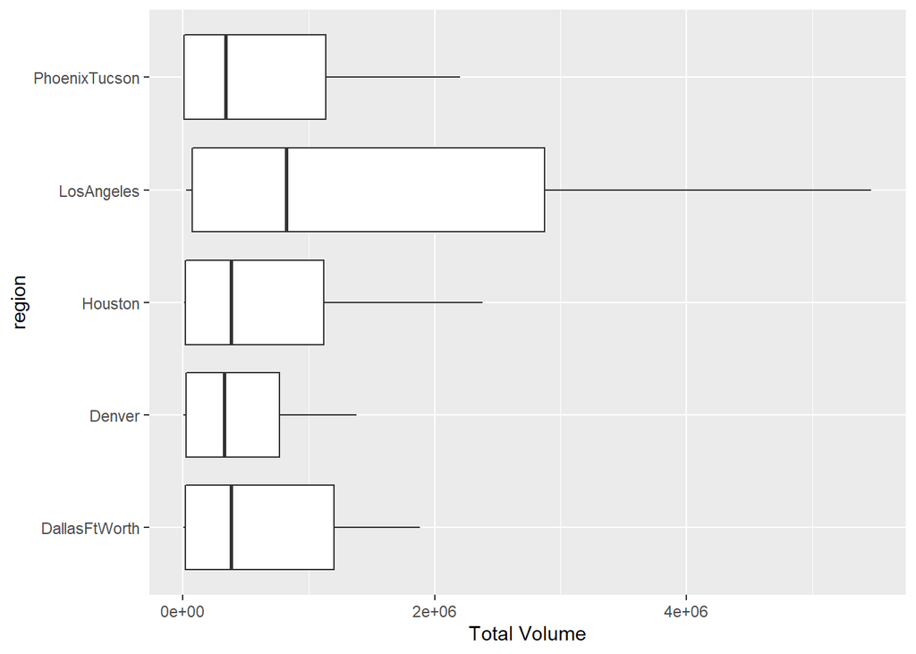

```r
avocados_metropolitan |>
  semi_join(big_metro, by = "region") |>
  ggplot(mapping = aes(x = `Total Volume`, y = region)) +
  geom_boxplot()
```

Dallas, Denver, Pheonix, Houston and Los Angeles were the metro areas with the highest avocado consumption.

## Question 6)

```r
ca_cities <- data.frame(region = c("LosAngeles", "SanFrancisco", "SanDiego", "Sacramento"))

avocados_metropolitan |>
  semi_join(ca_cities, by = "region") |>
  group_by(region, type) |>
  summarise(avg_price_type = mean(AveragePrice), .groups = "keep") |>
  pivot_wider(names_from = type,
              values_from = avg_price_type) |>
  mutate(difference = organic - conventional) |>
  arrange(desc(difference))
```

```
# A tibble: 4 × 4
# Groups:   region [4]
  region       conventional organic difference
  <chr>               <dbl>   <dbl>      <dbl>
1 SanFrancisco        1.40     2.21      0.814
2 Sacramento          1.27     1.97      0.695
3 SanDiego            1.06     1.73      0.673
4 LosAngeles          0.976    1.46      0.479
```

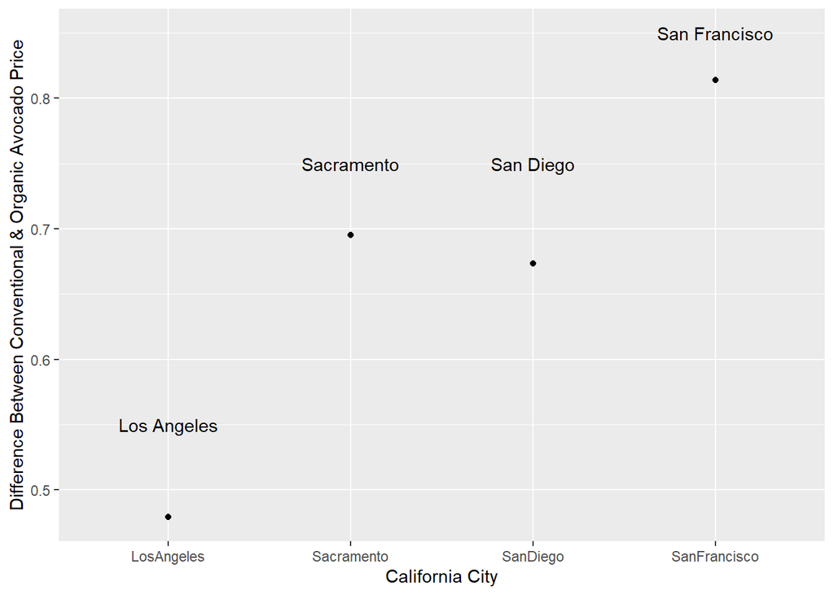

```r
avocados_metropolitan |>
  semi_join(ca_cities, by = "region") |>
  group_by(region, type) |>
  summarise(avg_price_type = mean(AveragePrice), .groups = "keep") |>
  pivot_wider(names_from = type,
              values_from = avg_price_type) |>
  mutate(difference = organic - conventional) |>
  ggplot(mapping = aes(y = difference, x = region, fill = region)) +
  geom_point() +
  annotate("text", x = 1, y = .55, label = "Los Angeles") +
  annotate("text", x = 2, y = .75, label = "Sacramento") +
  annotate("text", x = 3, y = .75, label = "San Diego") +
  annotate("text", x = 4, y = .85, label = "San Francisco") +
  theme(legend.position = "none") +
  labs(y = "Difference Between Conventional & Organic Avocado Price",
       x = "California City")
```

The city with the Largest difference in price between organic and conventional avocados was San Francisco. The average difference between the price of organic avocados as compared to organic was over $.80

## Question 7)

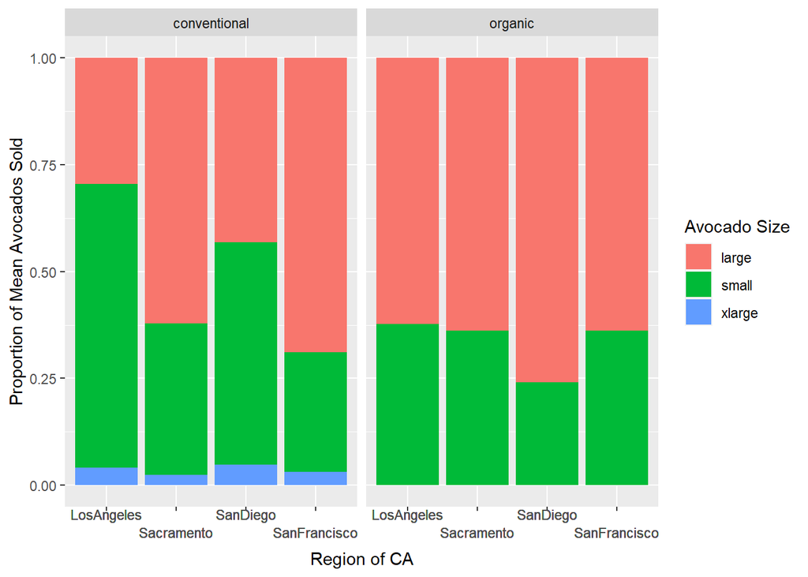

```r
avocados_metropolitan |>
  semi_join(ca_cities, by = "region") |>
  group_by(region, type) |>
  summarise(avg_volume = mean(`4046` + `4225` + `4770`), small = mean(`4046`),
            large = mean(`4225`), xlarge = mean(`4770`),
            .groups = "keep") |>
  pivot_longer(cols = c(small, large, xlarge),
               names_to = "size",
               values_to = "volume") |>
  mutate(proportion = volume/avg_volume) |>
    ggplot(mapping = aes(x = region, y = proportion, fill = size)) +
  geom_col() +
  facet_grid(. ~type) +
  theme(axis.text.x = element_text(vjust = grid::unit(c(-3, -1, -3, -1), "points"))) +
  labs(y = "Proportion of Mean Avocados Sold", x = "Region of CA", fill = "Avocado Size")
```